# R Notebook

```r
chocoladeTabel = read.csv("chocolade.csv")
```

```r
chocoladeTabel = read.csv("flavors_of_cacao.csv")
```

```r
str(chocoladeTabel)
```

```
'data.frame':   1795 obs. of  9 variables:
 $ Company...Maker.if.known.       : Factor w/ 416 levels "A. Morin","Acalli",..: 1 1 1 1 1 1 1 1 1 1 ...
 $ Specific.Bean.Origin.or.Bar.Name: Factor w/ 1039 levels "\"heirloom\", Arriba Nacional",..: 15 494 68 16 813 175 288 923 805 731 ...
 $ REF                             : int  1876 1676 1676 1680 1704 1315 1315 1315 1319 1319 ...
 $ Review.Date                     : int  2016 2015 2015 2015 2015 2014 2014 2014 2014 2014 ...
 $ Cocoa.Percent                   : num  63 70 70 70 70 70 70 70 70 70 ...
 $ Company.Location                : Factor w/ 60 levels "Amsterdam","Argentina",..: 19 19 19 19 19 19 19 19 19 19 ...
 $ Rating                          : num  3.75 2.75 3 3.5 3.5 2.75 3.5 3.5 3.75 4 ...
 $ Bean.Type                       : Factor w/ 42 levels ""," ","Amazon",..: 2 2 2 2 2 10 2 10 10 2 ...
 $ Broad.Bean.Origin               : Factor w/ 101 levels ""," ","Africa, Carribean, C. Am.",..: 70 80 80 80 57 93 18 93 93 57 ...
```

```r
correlatieAn <- chocoladeTabel[, c("REF","Review.Date","Rating", "Cocoa.Percent")]
```

```r
cor(correlatieAn)
```

```
                    REF Review.Date     Rating Cocoa.Percent
REF           1.0000000   0.9850759  0.1010298     0.0377912
Review.Date   0.9850759   1.0000000  0.0998465     0.0381769
Rating        0.1010298   0.0998465  1.0000000    -0.1648202
Cocoa.Percent 0.0377912   0.0381769 -0.1648202     1.0000000
```

## Wat er geconcludeerd kan worden uit deze correlatieanalyse is dat er uiteraard de REF samenhangt met de reviewdate. Dit komt omdat de REF een score is die toegewezen wordt op basis van de datum waar de beoordeling op is uitgevoerd. Waarbij een hogere score betekend dat de review dichterbij in het verleden plaatsvond. Vandaar dat het vrij logisch is dat er een hoge score van 0.99 uitkomt. Tevens is er een lichte correlatie tussen het percentage cacao in een reep en de uiteindelijke score die ze krijgen.

ANOVA: De afhankelijke variabelen die getest wordt is de rating. De onafhankelijke variablen zal de Specific.Bean.Origin.or.Bar.Name zijn. De business vraag is: ‘heeft het land van herkomst van een cacoaboon invloed op de rating van de chocoladereep?’

```r
install.packages("compute.es")
install.packages("car")
install.packages("ggplot2")
install.packages("multcomp")
install.packages("pastecs")
install.packages("WRS2")
```

```r
library("compute.es")
library("multcomp")
library("pastecs")
library("car")
library("ggplot2")
library("WRS2")
```

```r
by(chocoladeTabel$Rating,chocoladeTabel$Specific.Bean.Origin.or.Bar.Name, stat.desc)
```

[output not shown]

[output not shown]

[output cut: 6178 more lines]

[output not shown]

```r
leveneTest(chocoladeTabel$Rating, chocoladeTabel$Specific.Bean.Origin.or.Bar.Name, center=median)
```

```
Levene's Test for Homogeneity of Variance (center = median)
        Df F value Pr(>F)
group 1038  0.6564      1
       756
```

Volgens de levenetest zijn de varianties gelijk. Dus de assumptie van de gelijke variantie is voldaan.

```r
AnoModel<-aov(Rating ~ Specific.Bean.Origin.or.Bar.Name,data=chocoladeTabel)
summary(AnoModel)
```

```
                                   Df Sum Sq Mean Sq F value   Pr(>F)
Specific.Bean.Origin.or.Bar.Name 1038  267.5  0.2577   1.367 2.36e-06 ***
Residuals                         756  142.5  0.1885
---
Signif. codes:  0 ‘***’ 0.001 ‘**’ 0.01 ‘*’ 0.05 ‘.’ 0.1 ‘ ’ 1
```

[output not shown]

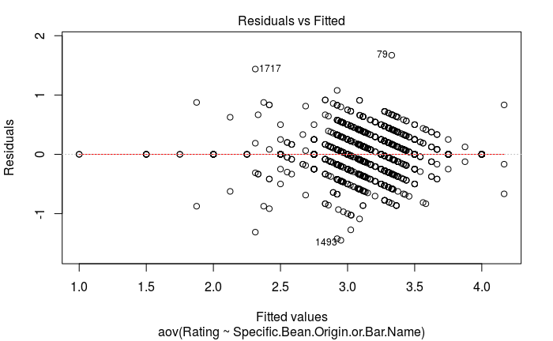

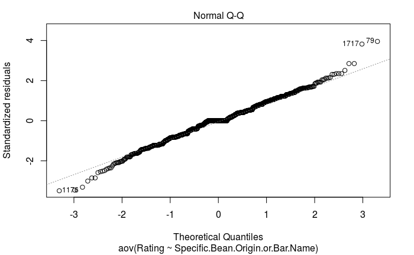

[output not shown]

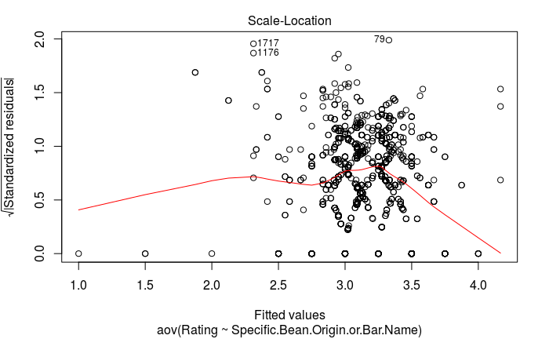

```
NaNs producedNaNs produced
```

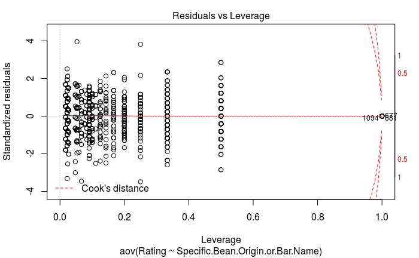

```r
plot(AnoModel)
```